# EDA ▶ Numerical Data Center, Spread, Outliers

February 04, 2020 @ 06:59 PM

## Before We Begin…

These slides are not meant to be standalone information. You should take notes to flesh out the contents. I recommend that you create an R Markdown document where you can combine information and code from the slides and your own additional notes and explorations to make connections.

**Related Materials**

- Ch 2 of *Mathematical Statistics with Resampling and R, 2<sup>nd</sup> Ed.*
- Ch 2 of [*Modern Dive*](https://moderndive.com/2-viz.html)
- Ch 3 of [*Modern Dive*](https://moderndive.com/3-wrangling.html)
- Ch 4 of [*Modern Dive*](https://moderndive.com/4-tidy.html)
- DataCamp [Introduction to Data](https://www.datacamp.com/courses/introduction-to-data)
- DataCamp [Introduction to the Tidyverse](https://www.datacamp.com/courses/introduction-to-the-tidyverse)

## How We Describe Distributions

**Categorical Variables**

- frequency / relative frequency

*Summaries based on counting how many times categories occur.*

**Quantitative Variables**

- shape
- center
- spread
- outliers

*Shape, center, and spread characterize the pattern of numerical observations. Outliers are deviations from the pattern.*

## Center

- mean
  - arithmetic mean ("average", *expected value*)
  - weighted mean
  - trimmed mean
  - geometric mean (n<sup>th</sup> root of the product)
- median (50<sup>th</sup> percentile/quantile)
- mode (we use this more with reference to shape)

Mean and median are both the "middle" of a given distribution, but the two summaries define middle or *center* differently. If a distribution is perfectly symmetric, mean = median.

## Spread

- variance
  - population
  - sample
- standard deviation
- mean absolute deviation (mad)
- median absolute deviation (*also* mad?)
- interquartile range (IQR)
- range

Summarizing the deviations of a set of values from some center point (like a mean) is a common technique in statistics.

## Measures Based on Moments

In physics, a moment of force is the turning effect of the force about a central point, as a function of distance from the point. Statistical moments are a similar idea.

mean (first moment)

- the mean \(\mu\) is the value that makes \(\Sigma(X - \mu)^1 = 0\) true
- mean is the center of mass or *balance point* of a distribution

variance (second moment)

\[M_2 = \sigma^2 = \frac{\Sigma(X - \mu)^2}{n}\]

\[\text{standard deviation} = \sqrt{\text{variance}} = \sigma \]

## Population vs. Sample Variance

The previous slide shows the formula for *population* variance.

When computing sample variance, we make a small change to the formula so that it is an *unbiased* estimator of the population variance (i.e., in the long run sample variance will neither over- nor under-estimate population variance).

\[\text{sample variance} = s^2 = \frac{\Sigma(x_i - \bar{x})^2}{n-1}\]

\[\text{sample standard deviation} = \sqrt{\text{sample variance}} = s\]

Recall we use different symbols for parameters versus statistics. If you are not yet familiar with the symbols for mean, variance, standard deviation, and sample size, this is a good time to learn!

## Z-Score (Standardized Score)

Mean and standard deviation have the same units as the data points they are summarizing (e.g., data in inches have a mean expressed in inches).

However, standard deviation itself can be a unit of measure. A z-score tells us how many standard deviations above or below the mean a given point is located.

\[z = \frac{X - \mu}{\sigma} \text{ (population)}\]

\[z = \frac{x - \bar{x}}{s} \text{ (in a sample)}\]

The data units cancel out. A z-score of +2 would be interpreted as "two standard deviations above the mean".

## Skewness and Kurtosis

skewness (third moment)

\[M_3 = \frac{\Sigma(X - \mu)^3}{n}\]

\[skewness = \frac{\Sigma(X - \mu)^3}{\sigma^3}\]

kurtosis (fourth moment)

\[M_4 = \frac{\Sigma(X - \mu)^4}{n}\]

\[kurtosis = \frac{\Sigma(X - \mu)^4}{\sigma^4}\]

## Moment-Based Summaries in R

- `mean()`
- `var()`
- `sd()`
- `skewness()`
- `kurtosis()`

The `var()` and `sd()` functions calculate sample variance and standard deviation. How could you get population variance if your data were a population?

The `skewness()` and `kurtosis()` functions are found in the `moments` package, not base `R`.

You should explore the syntax and output of these functions.

## Some Data to Summarize

Read gasmileage.csv, oldfaithful.csv, and Bangladesh.csv into RStudio. Remember you need `library(tidyverse)` for many of the functions we will use, including `read_csv()`. In coming slides they will be referred to by the following names.

- mileage: results of 100 EPA gas mileage tests for a particular model of car, in miles per gallon (mpg)
- geyser: eruption data for Old Faithful geyser in Yellowstone National Park, including duration in minutes and number of minutes until the next eruption.
- wells: concentration of three contaminants for a sample of wells in Bangladesh, in parts per million (ppm)

```r
glimpse(geyser)
```

```
Observations: 272
Variables: 2
$ erupt_time <dbl> 3.600, 1.800, 3.333, 2.283, 4.533, 2.883, 4.700, 3.600, 1.…
$ wait_time  <dbl> 79, 54, 74, 62, 85, 55, 88, 85, 51, 85, 54, 84, 78, 47, 83…
```

```r
glimpse(wells)
```

```
Observations: 271
Variables: 3
$ Arsenic  <dbl> 2400, 6, 904, 321, 1280, 151, 141, 1050, 511, 688, 81, 8, 37…
$ Chlorine <dbl> 6.2, 116.0, 14.8, 35.9, 18.9, 7.8, 56.3, 16.0, 40.4, 29.3, 3…
$ Cobalt   <dbl> 0.42, 0.45, 0.63, 0.68, 0.58, 0.35, 0.46, 0.59, 0.48, 0.87, …
```

You should also `glimpse()` the `mileage` dataset, which has only one variable: `mpg`.

## Measures Based on Ordered Counts

- five-number-summary
  - minimum
  - first quartile (Q<sub>1</sub>)
  - median
  - third quartile (Q<sub>3</sub>)
  - maximum
- interquartile range (IQR)
- range
- percentiles / quantiles

## Count-Based Summaries in R

- `fivenum()`
- `min()`
- `median()`
- `max()`
- `IQR()`
- `range()`
- `quantile()`

Again, you should explore the syntax, parameters, and output of each function to understand how it works.

## Summarizing Using `dplyr`

```r
mileage %>% summarize(n    = n(),
                      xbar = mean(mpg, na.rm = TRUE),
                      s    = sd(mpg, na.rm = TRUE),
                      min  = fivenum(mpg)[1],
                      Q1   = fivenum(mpg)[2],
                      med  = fivenum(mpg)[3],
                      Q3   = fivenum(mpg)[4],
                      max  = fivenum(mpg)[5],
                      skew = skewness(mpg, na.rm = TRUE),
                      kurt = kurtosis(mpg, na.rm = TRUE))
```

```
# A tibble: 1 x 10
      n  xbar     s   min    Q1   med    Q3   max   skew  kurt
  <int> <dbl> <dbl> <dbl> <dbl> <dbl> <dbl> <dbl>  <dbl> <dbl>
1   100  37.0  2.42    30  35.7    37  38.3  44.9 0.0501  3.67
```

## Z-Scores with `dplyr`

```r
xbar <- mean(mileage$mpg)
s    <- sd(mileage$mpg)
mileage <- mileage %>% mutate(zscores = (mpg - xbar)/s)
head(mileage)
```

```
# A tibble: 6 x 2
    mpg zscores
  <dbl>   <dbl>
1  36.3 -0.287
2  41    1.66
3  36.9 -0.0389
4  37.1  0.0438
5  44.9  3.27
6  36.8 -0.0802
```

## Boxplots and Outliers

One of the most common rules for determining outliers is based on the five-number summary. We can visualize the five-number summary and outliers in a boxplot.

[figure not shown]

## Calculating the Fences

Lower and upper fences determine the cutoff boundaries for small and large outliers as a function of spread.

```r
(lowerFence <- fivenum(mileage$mpg)[2] - 1.5 * IQR(mileage$mpg))
```

```
[1] 31.675
```

```r
(upperFence <- fivenum(mileage$mpg)[4] + 1.5 * IQR(mileage$mpg))
```

```
[1] 42.325
```

```r
boxplot.stats(sort(mileage$mpg))$out
```

```
[1] 30.0 44.9
```

## Calculating the Fences in `dplyr`

```r
mileage %>%
  summarize(lower_fence = fivenum(mpg)[2] - 1.5 * IQR(mpg),
            upper_fence = fivenum(mpg)[4] + 1.5 * IQR(mpg))
```

```
# A tibble: 1 x 2
  lower_fence upper_fence
        <dbl>       <dbl>
1        31.7        42.3
```

Use `group_by()` before `summarize()` if you want the fences for separate subgroups in your dataset, or any grouped summaries.

You can also `filter()` the dataset for cases containing outliers using the fences, rather than simply using `boxplot.stats()` to print outlier values. Why might this be more beneficial?

## Boxplot for One Variable

Notice that the quantitative axis here is `y`, unlike histograms, densities, and ecdf plots. How does this plot show symmetry?

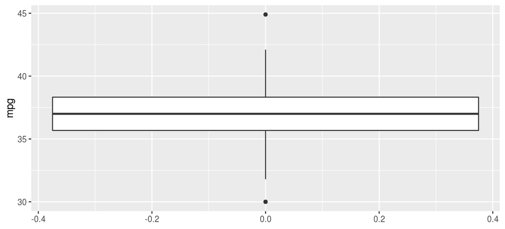

```r
ggplot(mileage, aes(y = mpg)) + geom_boxplot()
```

## Comparing Groups

Load the FlightDelays.csv dataset into RStudio. Let's compare!

```r
glimpse(flt_del)
```

```
Observations: 4,029
Variables: 10
$ ID           <dbl> 1, 2, 3, 4, 5, 6, 7, 8, 9, 10, 11, 12, 13, 14, 15, 16, 1…
$ Carrier      <chr> "UA", "UA", "UA", "UA", "UA", "UA", "UA", "UA", "UA", "U…
$ FlightNo     <dbl> 403, 405, 409, 511, 667, 669, 673, 677, 679, 681, 683, 6…
$ Destination  <chr> "DEN", "DEN", "DEN", "ORD", "ORD", "ORD", "ORD", "ORD", …
$ DepartTime   <chr> "4-8am", "8-Noon", "4-8pm", "8-Noon", "4-8am", "4-8am", …
$ Day          <chr> "Fri", "Fri", "Fri", "Fri", "Fri", "Fri", "Fri", "Fri", …
$ Month        <chr> "May", "May", "May", "May", "May", "May", "May", "May", …
$ FlightLength <dbl> 281, 277, 279, 158, 143, 150, 158, 160, 160, 163, 163, 1…
$ Delay        <dbl> -1, 102, 4, -2, -3, 0, -5, 0, 10, 60, 0, 32, 0, 44, 52, …
$ Delayed30    <chr> "No", "Yes", "No", "No", "No", "No", "No", "No", "No", "…
```

## Summarizing Flight Lengths by Carrier

```r
flt_del %>%
  group_by(Carrier) %>%
  summarize(n    = n(),
            xbar = mean(FlightLength, na.rm = TRUE),
            s    = sd(FlightLength, na.rm = TRUE),
            min  = fivenum(FlightLength)[1],
            Q1   = fivenum(FlightLength)[2],
            med  = fivenum(FlightLength)[3],
            Q3   = fivenum(FlightLength)[4],
            max  = fivenum(FlightLength)[5],
            iqr  = IQR(FlightLength, na.rm = TRUE))
```

```
# A tibble: 2 x 10
  Carrier     n  xbar     s   min    Q1   med    Q3   max   iqr
  <chr>   <int> <dbl> <dbl> <dbl> <dbl> <dbl> <dbl> <dbl> <dbl>
1 AA       2906  187.  36.1   140   155   175   228   250    73
2 UA       1123  181.  53.6    68   153   160   168   295    15
```

## Comparative Boxplots

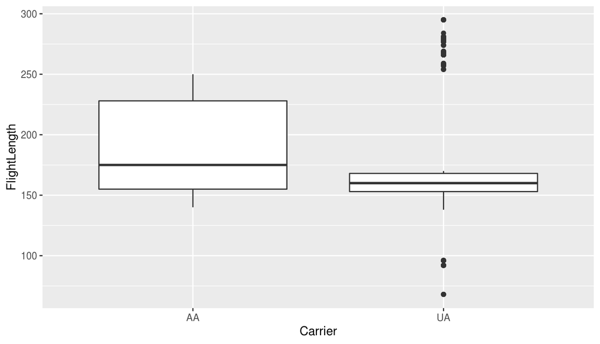

```r
ggplot(flt_del, aes(x = Carrier, y = FlightLength)) + geom_boxplot()
```

## Fences for Each Airline

```r
flt_del %>%
  group_by(Carrier) %>%
  summarize(LF = fivenum(FlightLength)[2] - 1.5 * IQR(FlightLength),
            UF = fivenum(FlightLength)[4] + 1.5 * IQR(FlightLength))
```

```
# A tibble: 2 x 3
  Carrier    LF    UF
  <chr>   <dbl> <dbl>
1 AA       45.5  338.
2 UA      130.   190.
```

Compare these values to the plots and summary statistics for the two airlines. Why are they different?

You may need to explore other variables in the dataset to fully answer this question.

## Comparative Boxplots Plus

Consider some of the options you learned when working with barplots in the Categorical Data slides or in DataCamp courses. They apply here as well.

```r
flt_del$Month <- factor(flt_del$Month, levels = c("May", "June"))

ggplot(flt_del, aes(x = Carrier, y = FlightLength, fill = Carrier)) +
  geom_boxplot() +
  facet_wrap(~ Month) +
  scale_x_discrete(labels = c("American", "United")) +
  scale_fill_manual(values = c("lightgreen", "lightblue")) +
  theme(legend.position = "none") +
  labs(title = "Length of AA and UA Flights from LGA in 2013",
       y = "Length of Flight (minutes)",
       caption = "Source: Chihara & Hesterberg, FlightDelays")
```

[output not shown]